# Human Activity Recognition

Alex M.

2/8/2021

## Executive Summary

The goal of this project is to predict the manner in which users of devices such as *Jawbone Up*, *Nike FuelBand*, and *Fitbit* did exercise.

The data collected from accelerometers on the belt, forearm, arm, and dumbell of 6 participants, who perform barbell lifts correctly and incorrectly, allow us to analyze how well they did the exercise.

## Loading the data

First, we are going to load the data:

- The training data: https://d396qusza40orc.cloudfront.net/predmachlearn/pml-training.csv We are going to use this training data set for fitting our models and choose the best algorithm.
- The test data : https://d396qusza40orc.cloudfront.net/predmachlearn/pml-testing.csv

We are going to use this data set for making a prediction based on the results of chosen model.

```r
library(dplyr)
```

```r
library(corrplot)
library(caret)
library(randomForest)
library(naniar)
set.seed(123)

#LOADING DATA
URLtrain<-"https://d396qusza40orc.cloudfront.net/predmachlearn/pml-training.csv"
URLtest<-"https://d396qusza40orc.cloudfront.net/predmachlearn/pml-testing.csv"

training<-read.csv(URLtrain)
testing<-read.csv(URLtest)

dim(training)
```

```
## [1] 19622   160
```

```r
dim(testing)
```

```
## [1]  20 160
```

As we can see we have a training data set with 19622 observations and 160 variables(including the class), and a testing data set of 20 observations and 160 variables, but now, we observe we don’t have the class variable instead we have an identification variable (problem_id), so we are going to predict the class.

## Partitioning the data

Now we are going to separate the training data set in two parts, one with the 70% of the data to fit our model, and the rest (30%) to evaluate the performance of the model.

```r
#dataset partition
dataindex <- createDataPartition(training$classe, p=0.7, list=FALSE)
traindata <- training[dataindex, ]
testdata <- training[-dataindex, ]
```

## Basic Exploratory Data Analysis

Next, we are going to do some basic explorations in the data sets

```r
#Data sets dimensions
dim(traindata)
```

```
## [1] 13737   160
```

```r
dim(testdata)
```

```
## [1] 5885  160
```

```r
#Let's look at the values of class variable that indicates how well the exercise is done
unique(traindata$classe)
```

```
## [1] "A" "B" "C" "D" "E"
```

```r
#look at data set structure
str(traindata)
```

```
## 'data.frame':    13737 obs. of  160 variables:
##  $ X                       : int  1 2 5 7 9 10 12 13 14 16 ...
##  $ user_name               : chr  "carlitos" "carlitos" "carlitos" "carlitos" ...
##  $ raw_timestamp_part_1    : int  1323084231 1323084231 1323084232 1323084232 1323084232 1323084232 1323084232 1323084232 1323084232 1323084232 ...
##  $ raw_timestamp_part_2    : int  788290 808298 196328 368296 484323 484434 528316 560359 576390 644302 ...
##  $ cvtd_timestamp          : chr  "05/12/2011 11:23" "05/12/2011 11:23" "05/12/2011 11:23" "05/12/2011 11:23" ...
##  $ new_window              : chr  "no" "no" "no" "no" ...
##  $ num_window              : int  11 11 12 12 12 12 12 12 12 12 ...
##  $ roll_belt               : num  1.41 1.41 1.48 1.42 1.43 1.45 1.43 1.42 1.42 1.48 ...
##  $ pitch_belt              : num  8.07 8.07 8.07 8.09 8.16 8.17 8.18 8.2 8.21 8.15 ...
##  $ yaw_belt                : num  -94.4 -94.4 -94.4 -94.4 -94.4 -94.4 -94.4 -94.4 -94.4 -94.4 ...
##  $ total_accel_belt        : int  3 3 3 3 3 3 3 3 3 3 ...
##  $ kurtosis_roll_belt      : chr  "" "" "" "" ...
##  $ kurtosis_picth_belt     : chr  "" "" "" "" ...
##  $ kurtosis_yaw_belt       : chr  "" "" "" "" ...
```

[output cut: 86 more lines]

As we can see, there are many variables with NAs and empty values.

### NAs and near zero variance Analysis

First, we are going to analyze the data with near zero variance…

```r
#exclude the near zero variance
NZV<-nearZeroVar(traindata)
length(NZV)
```

```
## [1] 53
```

As we can see, we have a lot of variables with variance near zero. This variables represent noisy information, so we can remove it from the train and test data sets…

```r
#exclude the near zero variance
traindata2<-traindata[,-NZV]
testdata2<-testdata[,-NZV]
dim(traindata2)
```

```
## [1] 13737   107
```

```r
dim(testdata2)
```

```
## [1] 5885  107
```

Now we are going to analyze the variables with most part of the data are NAs…

```r
#we have to analyze NAs and remove the ones with mostly NA
MostlyNA<-apply(is.na(traindata2), 2, mean)>0.95
sum(MostlyNA)
```

```
## [1] 48
```

Like we did with previously, we can remove this variables from our data sets…

```r
#removing mostly NAs variables
traindata3<-traindata2[, MostlyNA==FALSE]
testdata3<-testdata2[,MostlyNA==FALSE]
dim(traindata3)
```

```
## [1] 13737    59
```

```r
dim(testdata3)
```

```
## [1] 5885   59
```

Finally, we can exclude the first five variables (X, user_name…) from our data set, because they don’t bring useful information for fitting our model…

```r
#removing the first five vars

#removing from training data set
traindata4<-select(traindata3,-X,-user_name,-raw_timestamp_part_1,-raw_timestamp_part_2,-cvtd_timestamp)

#removing from test data set
testdata4<-select(testdata3,-X,-user_name,-raw_timestamp_part_1,-raw_timestamp_part_2,-cvtd_timestamp)

#final dimensions
dim(traindata4)
```

```
## [1] 13737    54
```

```r
dim(testdata4)
```

```
## [1] 5885   54
```

```r
#Summary with missing values
pct_miss(traindata4)
```

```
## [1] 0
```

```r
pct_miss(testdata4)
```

```
## [1] 0
```

Finally we have a data sets with 54 variables, and the percentage of missing value in data is zero.

For further analysis we can make a study of how highly correlated the variables are for making other data sets for better predictions.

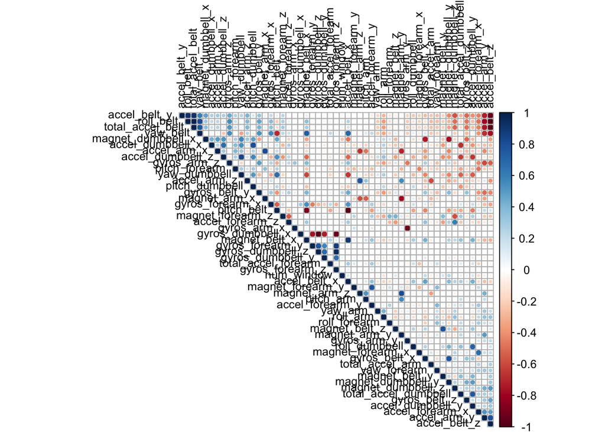

```r
corrplot(cor(select(traindata4,-classe)), order = "FPC",type = "upper",tl.cex = 0.8, tl.col = rgb(0, 0, 0))
```

## Machine Learning Algorythms

Next, we are going to fit two models with two different machine learning algorithms:

- Random Forest
- Generalized Boosted

In both cases we are using cross-validation methods.

Finally, we will choose the algorithm with better performance and we will use it to predict the class in the testing data set.

### Random Forest

First, we are going to fit a model using the Random Forest with cross-validation algorithm…

```r
#Converting the class variable to factor
traindata4$classe<-factor(traindata4$classe)
testdata4$classe<-factor(testdata4$classe)

#RANDOMFOREST + CV
set.seed(123)
kFolds <- trainControl(method = "cv", number = 10)
modFitRF<- train(classe ~ ., data=traindata4, method="rf",trControl=kFolds)
modFitRF
```

```
## Random Forest
##
## 13737 samples
##    53 predictor
##     5 classes: 'A', 'B', 'C', 'D', 'E'
##
## No pre-processing
## Resampling: Cross-Validated (10 fold)
## Summary of sample sizes: 12362, 12363, 12364, 12364, 12364, 12363, ...
## Resampling results across tuning parameters:
##
##   mtry  Accuracy   Kappa
##    2    0.9938849  0.9922647
##   27    0.9973790  0.9966847
##   53    0.9962141  0.9952112
##
## Accuracy was used to select the optimal model using the largest value.
## The final value used for the model was mtry = 27.
```

We observe that we obtain a very high accuracy and Kappa values, and we get the maximum accuracy when the number of variables randomly sampled as candidates at each split is 27…

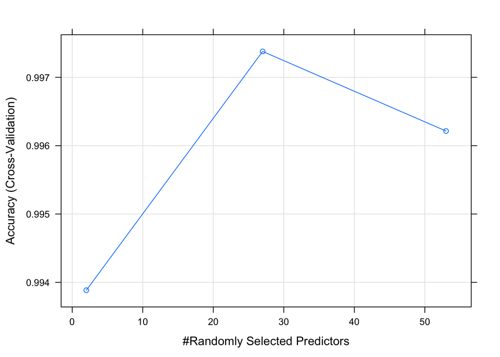

```r
plot(modFitRF)
```

Next, we are going to make a prediction with the test data set partition…

```r
#prediction on Test dataset
predictRF <- predict(modFitRF, newdata=testdata4)

#Confusion Matrix
confMatRF <- confusionMatrix(predictRF, testdata4$classe)
confMatRF
```

```
## Confusion Matrix and Statistics
##
##           Reference
## Prediction    A    B    C    D    E
##          A 1674    2    0    0    0
##          B    0 1134    2    0    0
##          C    0    3 1024    1    0
##          D    0    0    0  963    4
##          E    0    0    0    0 1078
##
## Overall Statistics
##
##                Accuracy : 0.998
##                  95% CI : (0.9964, 0.9989)
##     No Information Rate : 0.2845
##     P-Value [Acc > NIR] : < 2.2e-16
##
##                   Kappa : 0.9974
##
##  Mcnemar's Test P-Value : NA
##
## Statistics by Class:
##
##                      Class: A Class: B Class: C Class: D Class: E
## Sensitivity            1.0000   0.9956   0.9981   0.9990   0.9963
## Specificity            0.9995   0.9996   0.9992   0.9992   1.0000
## Pos Pred Value         0.9988   0.9982   0.9961   0.9959   1.0000
## Neg Pred Value         1.0000   0.9989   0.9996   0.9998   0.9992
## Prevalence             0.2845   0.1935   0.1743   0.1638   0.1839
## Detection Rate         0.2845   0.1927   0.1740   0.1636   0.1832
## Detection Prevalence   0.2848   0.1930   0.1747   0.1643   0.1832
## Balanced Accuracy      0.9998   0.9976   0.9986   0.9991   0.9982
```

As we can see in the confusion matrix, we have only 12 observations incorrectly classified, so we have a very high accuracy and a Kappa value near 1.

### Generalized Boosted

Now, we are going to fit anothe model using the Generalized Boosted with cross-validation algorithm

```r
#PREDICTION GENERALIZED BOOSTED with CV
set.seed(123)
controlGBM <- trainControl(method = "repeatedcv", number = 5, repeats = 1)
modFitGBM  <- train(classe ~ ., data=traindata4, method = "gbm",trControl = controlGBM, verbose = FALSE)
modFitGBM
```

```
## Stochastic Gradient Boosting
##
## 13737 samples
##    53 predictor
##     5 classes: 'A', 'B', 'C', 'D', 'E'
##
## No pre-processing
## Resampling: Cross-Validated (5 fold, repeated 1 times)
## Summary of sample sizes: 10990, 10990, 10988, 10990, 10990
## Resampling results across tuning parameters:
##
##   interaction.depth  n.trees  Accuracy   Kappa
##   1                   50      0.7613751  0.6972987
##   1                  100      0.8315499  0.7867325
##   1                  150      0.8696235  0.8350010
##   2                   50      0.8828719  0.8516623
##   2                  100      0.9380512  0.9216034
##   2                  150      0.9641849  0.9546825
##   3                   50      0.9327376  0.9148565
##   3                  100      0.9719009  0.9644492
##   3                  150      0.9855866  0.9817668
##
## Tuning parameter 'shrinkage' was held constant at a value of 0.1
##
## Tuning parameter 'n.minobsinnode' was held constant at a value of 10
## Accuracy was used to select the optimal model using the largest value.
## The final values used for the model were n.trees = 150, interaction.depth =
##  3, shrinkage = 0.1 and n.minobsinnode = 10.
```

We observe that we obtain a very high accuracy and Kappa values with 150 trees and 3 iterations in depth….

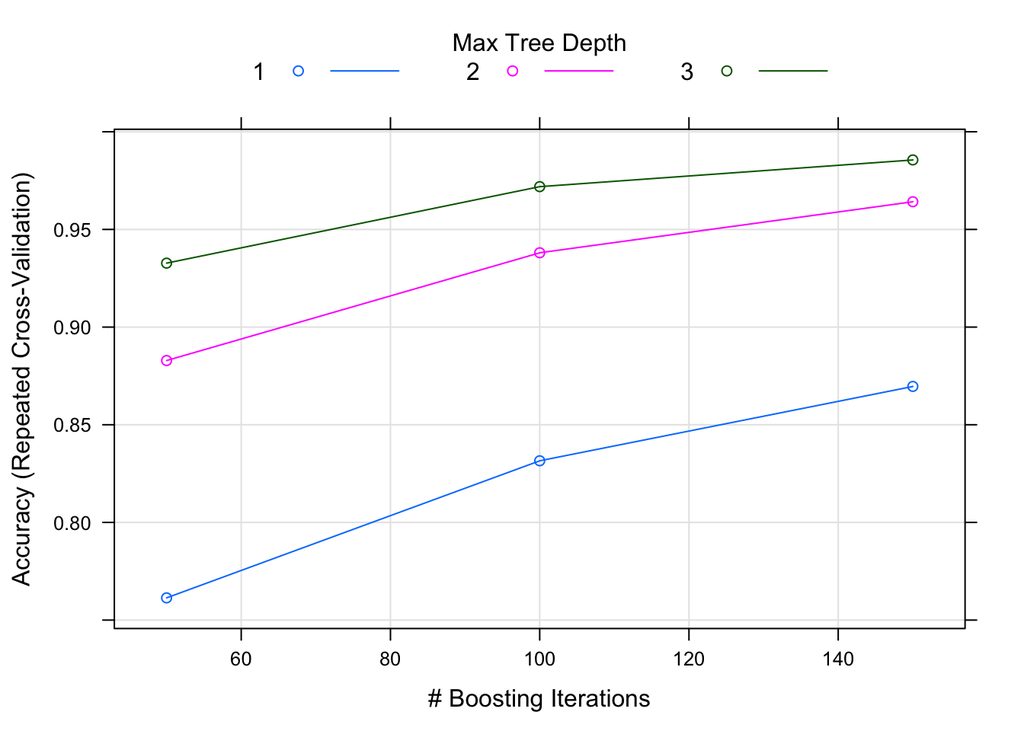

```r
plot(modFitGBM)
```

```r
# prediction on Test dataset
predictGBM <- predict(modFitGBM, newdata=testdata4)
confMatGBM <- confusionMatrix(predictGBM, testdata4$classe)
confMatGBM
```

```
## Confusion Matrix and Statistics
##
##           Reference
## Prediction    A    B    C    D    E
##          A 1673    9    0    1    0
##          B    1 1116    7    6    1
##          C    0   12 1016   11    7
##          D    0    2    3  945    9
##          E    0    0    0    1 1065
##
## Overall Statistics
##
##                Accuracy : 0.9881
##                  95% CI : (0.985, 0.9907)
##     No Information Rate : 0.2845
##     P-Value [Acc > NIR] : < 2.2e-16
##
##                   Kappa : 0.985
##
##  Mcnemar's Test P-Value : NA
##
## Statistics by Class:
##
##                      Class: A Class: B Class: C Class: D Class: E
## Sensitivity            0.9994   0.9798   0.9903   0.9803   0.9843
## Specificity            0.9976   0.9968   0.9938   0.9972   0.9998
## Pos Pred Value         0.9941   0.9867   0.9713   0.9854   0.9991
## Neg Pred Value         0.9998   0.9952   0.9979   0.9961   0.9965
## Prevalence             0.2845   0.1935   0.1743   0.1638   0.1839
## Detection Rate         0.2843   0.1896   0.1726   0.1606   0.1810
## Detection Prevalence   0.2860   0.1922   0.1777   0.1630   0.1811
## Balanced Accuracy      0.9985   0.9883   0.9920   0.9887   0.9920
```

## Final Conclusions

Now we can compare the accuracy and kappa values we have obtained in each model. The kappa coefficient measures the agreement between classification and truth values. So a kappa value near of 1 (or 100%) represents perfect agreement.

First we observe that the Random Forest model has a very high accuracy and kappa values…

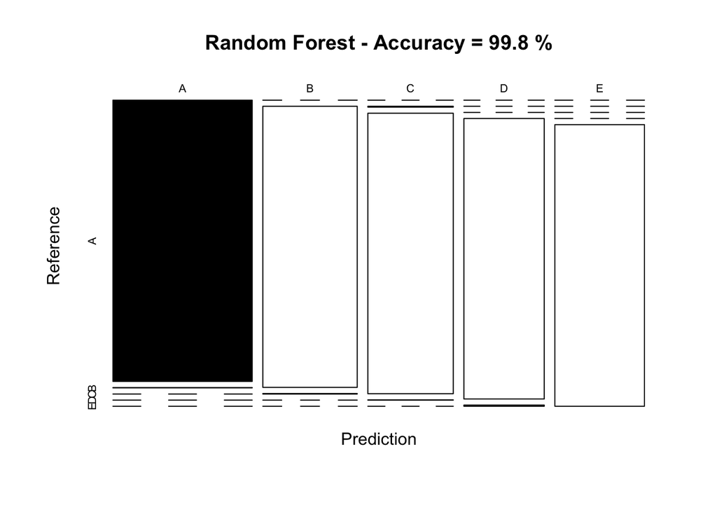

```r
plot(confMatRF$table, col = confMatRF$byClass, main = paste("Random Forest - Accuracy =",round(confMatRF$overall['Accuracy']*100, 2),"%"))
```

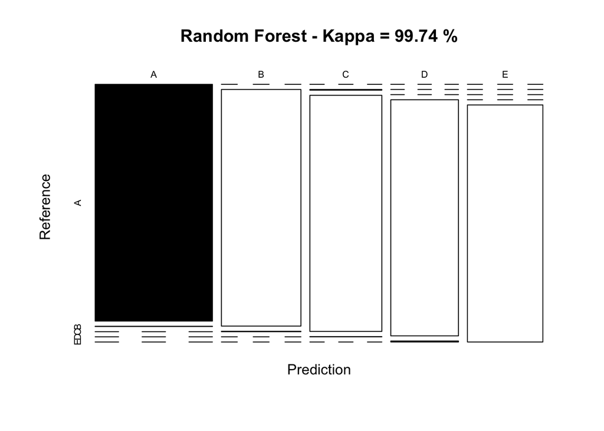

```r
plot(confMatRF$table, col = confMatRF$byClass, main = paste("Random Forest - Kappa =",round(confMatRF$overall['Kappa']*100, 2),"%"))
```

Lets see now the values obtained with the Generalized Boosted model…

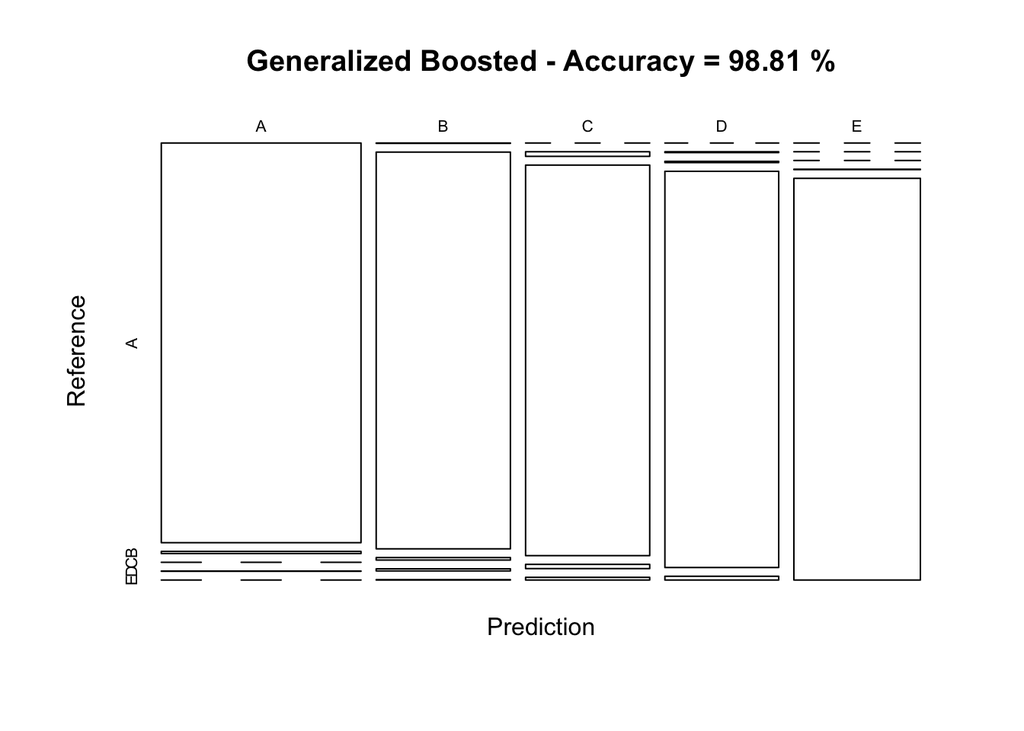

```r
plot(confMatGBM$table, col = confMatGBM$byClass, main = paste("Generalized Boosted - Accuracy =",round(confMatGBM$overall['Accuracy']*100, 2),"%"))
```

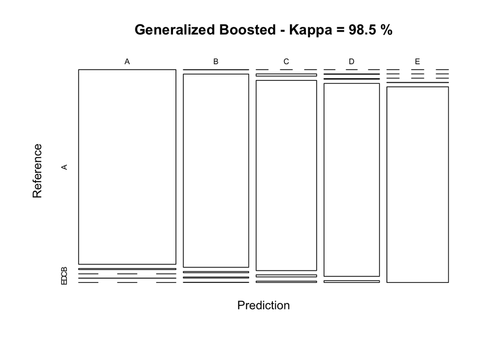

```r
plot(confMatGBM$table, col = confMatGBM$byClass, main = paste("Generalized Boosted - Kappa =",round(confMatGBM$overall['Kappa']*100, 2),"%"))
```

We can conclude that the Random Forest model has a better performance than the Generalized Boosted model with higher accuracy and Kappa values.

## Final Prediction

Finally we are going to predict the class of the testing data set using the Random Forest fitted model

```r
predictTesting <- predict(modFitRF, newdata=testing)
predictTesting
```

```
##  [1] B A B A A E D B A A B C B A E E A B B B
## Levels: A B C D E
```